# academia project idea: artificial intelligence

- If you want the source ("jupyter ipython notebook") to run this notebook, download at https://www.dropbox.com/s/z68hyu8dtwsgkl7/20160302_AI_kickoff.ipynb?dl=0
- Without internet connection the comics and videos do not load.
- I put a stripped version of the source here if you really want to run the code yourself, but do not want to use notebooks https://dl.dropboxusercontent.com/u/29211873/20160302_AI_kickoff.py
- You need python3, numpy and matplotlib

[figure not shown]

## Demonstrations

### Virtual creatures

Made out of blocks coupled with joints are put into a world with gravity and friction. The goal that defines their fitness is changed and the video shows the creatures as they adapt to the changing demands of their environment.

```python
from IPython.display import YouTubeVideo
YouTubeVideo("CQVjS-PT_c4", start=0, end=105)
```

[video not shown]

### AlphaGo

- the average number of moves per game is around 300 (chess: 80)
- the average branching factor at each turn is around 235 (chess: 35)

```python
YouTubeVideo("IFmj5M5Q5jg", stat=0, end=120)
```

[video not shown]

### MarI/O

Evolutionary algorithm and neural networks combined: http://nn.cs.utexas.edu/downloads/papers/stanley.ec02.pdf

```python
YouTubeVideo("qv6UVOQ0F44")
```

[video not shown]

### A Neural Algorithm of Artistic Style

http://arxiv.org/abs/1508.06576 Leon A. Gatys, Alexander S. Ecker, Matthias Bethge (2015)

In fine art, especially painting, humans have mastered the skill to create unique visual experiences through composing a complex interplay between the content and style of an image. Thus far the algorithmic basis of this process is unknown and there exists no artificial system with similar capabilities. However, in other key areas of visual perception such as object and face recognition near-human performance was recently demonstrated by a class of biologically inspired vision models called Deep Neural Networks. Here we introduce an artificial system based on a Deep Neural Network that creates artistic images of high perceptual quality. The system uses neural representations to separate and recombine content and style of arbitrary images, providing a neural algorithm for the creation of artistic images. Moreover, in light of the striking similarities between performance-optimised artificial neural networks and biological vision, our work offers a path forward to an algorithmic understanding of how humans create and perceive artistic imagery.

[figure not shown]

```python
from IPython.display import Image
Image(filename='deepart_io.png')
```

## Now let's try it out: evolutionary algorithm

Want to find the mountain top in a static landscape. Use population of points that are evolved according to a fitness function.

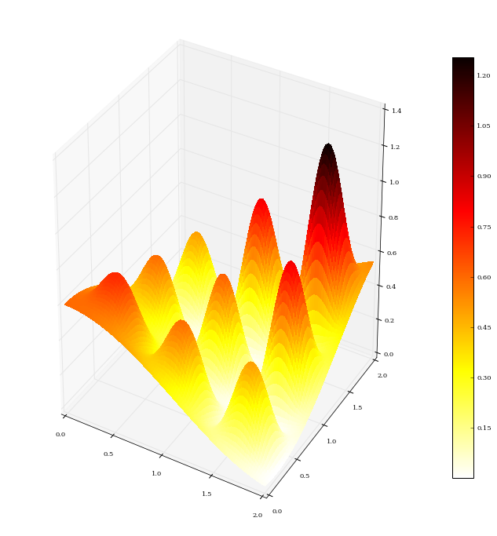

```python
# Load stuff from external sources.
import numpy as np # Library with arrays
import matplotlib as mpl # Plots
mpl.rcParams['text.usetex'] = False # rc param kniup
from mpl_toolkits.mplot3d import Axes3D # 3D-plot
import matplotlib.pyplot as plt #plot
# draw plots right into this notebook
%matplotlib inline

# Now generate the landscape
π = np.pi
ω = 2*π*0.75
xstart = 0; xend = 2
x = np.linspace(0,2,100)
y = np.linspace(0,2,100)
def hillscape(x,y):
    return np.sin(ω*x)**2*np.sin(ω*y)**2 * np.exp(-((x-2)**2+(y-2)**2)/(4)) + 0.6*np.cos(abs(x+y)/1.41)**2

# 3D Plot of hillscape
X, Y = np.meshgrid(x, y)
Z = hillscape(X,Y)
fig = plt.figure(figsize=(12,12))
ax = fig.gca(projection='3d')
surf = ax.plot_surface(X, Y, Z, rstride=1, cstride=1, cmap=mpl.cm.hot_r,
                       linewidth=0, antialiased=False)
fig.colorbar(surf, shrink=0.8, aspect=20)
```

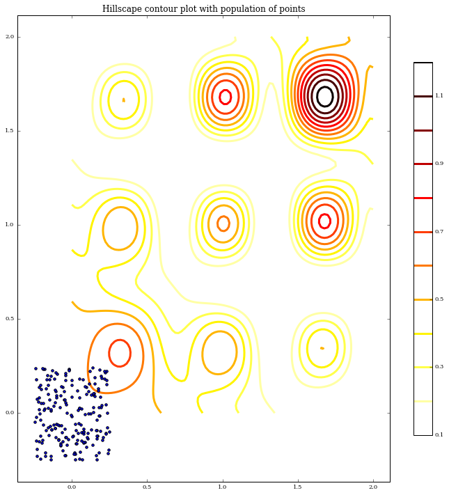

```python
#Start with random population of initial points
population_size = 200
dim = 2
points = np.random.rand(population_size, dim)
points = (points -0.5)/2 # Put them into te lower left corner

# And draw them into a contour plot of the landscape
result = hillscape(x[:,None], y[None,:])
plt.figure(figsize=(12,12))
CS = plt.contour(x, y, result, 12, label='hillscape',  linewidths=3, cmap=mpl.cm.hot_r)
plt.title('Hillscape contour plot with population of points')
CB = plt.colorbar(CS, shrink=0.8, extend='both')
plt.scatter(points[:,0], points[:,1], marker='o', c='b', s=12, zorder=2)
```

```python
# Evolution parameters
mutation_maxsize = 2
mutation_probability = 4/population_size
death_rate = 10/population_size
reproduction_rate = death_rate # please no changerino
boundary_condition = True
diversity_reward = True
diversity_weight = 0.5
fitness_weight = 1

# Define the functions that are used for the evolution
def mutate(points):
    mutation_occurs = np.random.rand(population_size, 2) < mutation_probability
    mutations = (np.random.rand(population_size, 2) - 0.5) * mutation_maxsize
    mutated_points = points + mutation_occurs * mutations
    return mutated_points

def boundary(points):
    inside_range = np.logical_and(points >= 0, points <= 2)
    points_inside = np.logical_and(inside_range[:,0], inside_range[:,1])
    return points_inside

def diversity(points):
    mean_x = np.mean(points[:,0])
    mean_y = np.mean(points[:,1])
    diversity_score = np.sqrt((points[:,0] - mean_x)**2 + (points[:,1] - mean_y)**2)
    return diversity_score * diversity_weight / 2

# Sorts points in order of incresing fitness = increasing goodness
def fitness_ranking(points):
    fitness = hillscape(points[:,0], points[:,1]) * fitness_weight
    if diversity_reward:
        fitness = fitness + diversity(points)
    if boundary_condition:
        fitness = fitness * boundary(points)
    ranking = np.argsort(fitness)
    ranked_points = points[ranking]
    return ranked_points

def crossover(a, b):
    p = np.random.rand()
    crossed_a = a; crossed_b = b
    if p < 1/4:
        # swap x values
        crossed_a[0] = b[0]
        crossed_b[0] = a[0]
    elif p < 2/4:
        # swap y values
        crossed_a[1] = b[1]
        crossed_b[1] = a[1]
    else:
        #swap x-y values
        crossed_a[0] = b[1]
        crossed_b[1] = a[0]
    return crossed_a, crossed_b

def reproduction_and_death(ranked_points):
    to_crossover = np.arange(0, int(population_size * death_rate), 1)
    n = len(to_crossover)
    if n % 2:
        print('Warning: odd numeber of points to cross')
        to_crossover = np.arange(0, int(population_size * death_rate -1), 1)
    # Chose random pairs to cross
    order = np.random.rand(n)
    order = np.argsort(order) + 1
    for i in np.arange(0, n, 2):
        a = ranked_points[-order[i]]
        b = ranked_points[-order[i+1]]
        x, y = crossover(a, b)
        # Replace worst points with offspring
        ranked_points[i] = x
        ranked_points[i+1] = y
    return ranked_points
```

```python
#Start with random population of initial points (repeated here for convenience)
points = np.random.rand(population_size, dim)
points = (points -0.5)/2
```

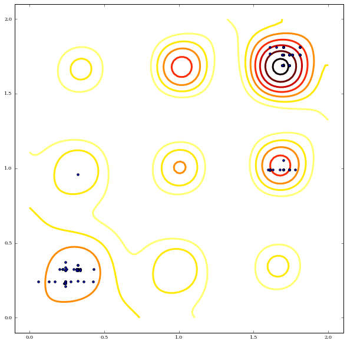

```python
# Wrap up the functions above into this easy to use caller
def evolve(points):
    # Add random mutations to some random set of points
    mutated_points = mutate(points)
    # Rank the points according to their fitness
    ranked_points = fitness_ranking(mutated_points)
    # Let the best points reproduce. Crossover happens.
    # Their offspring replaces the worst few points.
    evolved_points = reproduction_and_death(ranked_points)
    # Hand back the evolved points
    return evolved_points

# Number of generations to evolve
generations = 20
# Variable to save the history of the evolution steps
history = [points]
# Make a contour plot with the landscape
plt.figure(figsize=(10,10))
CS = plt.contour(x, y, result, 10, label='hillscape',  linewidths=3, cmap=mpl.cm.hot_r)
# Iterate over #generations, here it actually happens
for i in range(generations):
    evolved_points = evolve(points)
    #history.append([evolved_points]) #disabled
    points = evolved_points

# Testing stuff
f = hillscape(points[:,0], points[:,1])
d = diversity(points)
b = boundary(points)
#print('fitness: ', f, 'diversity: ', d, 'boundary: ', b)
#print('Total scores: ', (f*fitness_weight+d*diversity_weight)*(b*1))

# Draw the evolved points into the landscape
plt.scatter(points[:,0], points[:,1], marker='o', c='b', s=12, zorder=2)
```

## Specific ideas for a relevant project:

- identification of blüemli? enzian?
- any image object recognition task (very hard in general...)
- Optimization problems Geoseismik, Atmosphärenphysik, Seen, Myonen, ...
- Learn how to code!
- data analysis, identify sound? phones?
- artificial plants/creatures? Can EA's be shifted towards imitating nature more accurately?
- text/language processing - can we train a NN to correct academia reports?
- Play some game ai? Try to explain some feature of another project?
- Go away from the traditional academia project model?

## THE TEAM

### Andrino, Knüppi, Raphi, Sophia

```python
# Introduction to human vision
YouTubeVideo("hZED73seTQE")
```

[video not shown]

[figure not shown]